# Analiza danych migracyjnych

3 czerwca 2019

## Spis treści

1. Źródła
2. Wskaźnik PKB na świecie
3. Wskaźnik HDI na świecie
4. Pierwsze wnioski
5. Najpopularniejsze cele migracyjne
6. Migracja na świecie
7. Dalsze wnioskowanie
8. Analiza danych migracyjnych na przykładzie – Ukraina
9. Podsumowanie
10. Bonus

## Dwa słowa o źródłach

Na potrzeby projektu zdecydowaliśmy się na skorzystanie z danych dostępnych na stronach:  
**Travel, Politics i Expatriates Stack Exchange** .  
Dostępne na stackach zasoby rozszerzyliśmy o dane pochodzące z:

- **Banku Światowego**,
- **rankingu Mercera najlepszych miast do życia**,

## PKB na świecie

[interactive chart not shown]

## HDI na świecie

[interactive chart not shown]

## Przewidywania

Biorąc pod uwagę tak istotne zróżnicowanie w poziomie rozwoju gospodarczego państw świata, prognozować należy silne przepływy migracyjne w ogromnej skali.

W szczególności spodziewać się można silnych ruchów migracyjnych z państw o najniższym PKB.

Można się spodziewać, że państwa o najwyższych wartościach wskaźników znajdą się w czołówce państw docelowych, a głównymi wysyłającymi okażą się państwa afrykańskie oraz południowo-azjatyckie.

## Migracja na swiecie

[interactive chart not shown]

## Czy dane ze stacka Expatriats pokrywaja się z danymi na świecie dotyczącymi migracji?

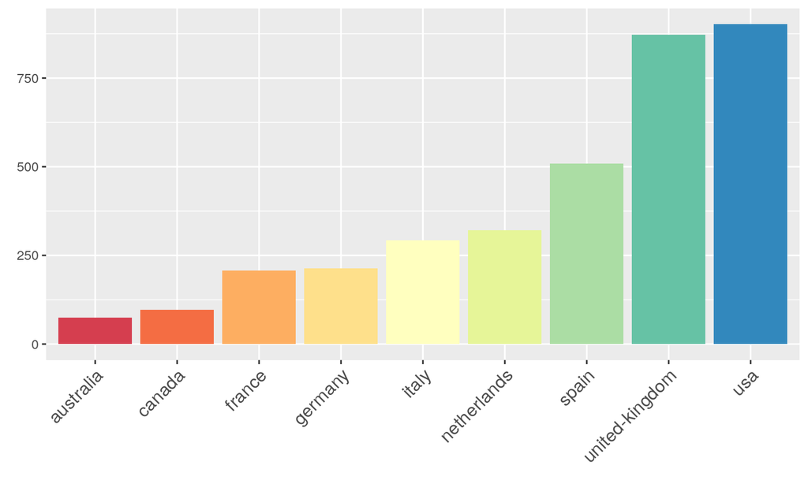

## Analiza na konkretnym przykladzie - Ukraina

Aby uświadomić sobie jak dynamicznie zmieniającym się zjawiskiem jest światowa migracja wystarczy przeanalizować rozkład czasowy liczby postów dot. Ukrainy na różnych forach.

*Jak pod wpływem wojny zmieniło się zainteresowanie Ukrainą na stackach?*

*Jaki wpływ na to zainteresowanie ma upływający czas?*

Rozważmy to zagadnienie na podstawie forów Politics i Travel.

## Czy wybuch wojny na Ukrainie został zauważony na Stacku?

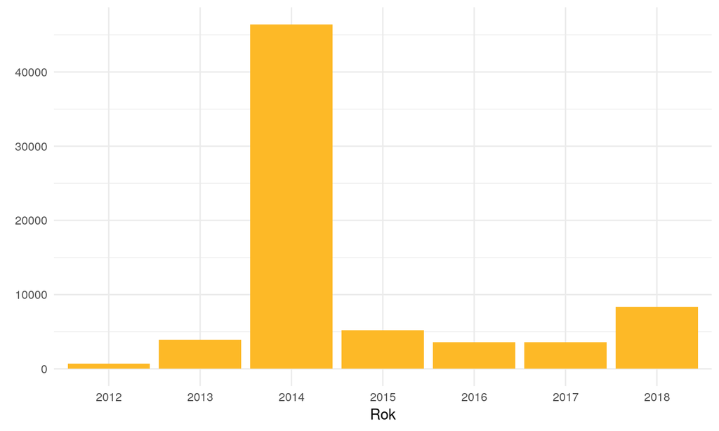

## Faktyczne dane o migracji dla Ukrainy

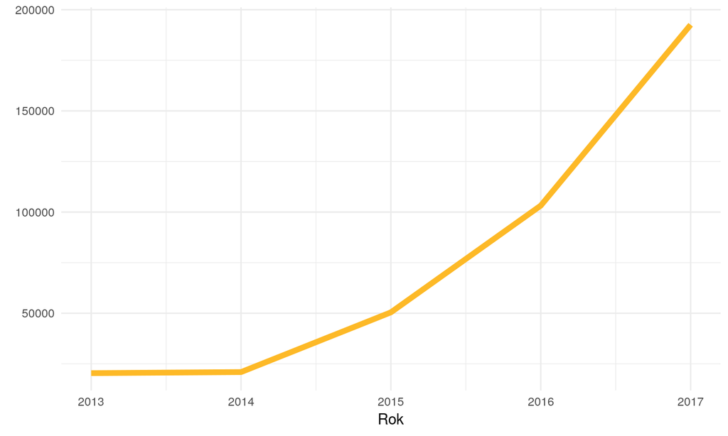

## Jak rozkładało się zainteresowanie podróżami na Ukrainę?

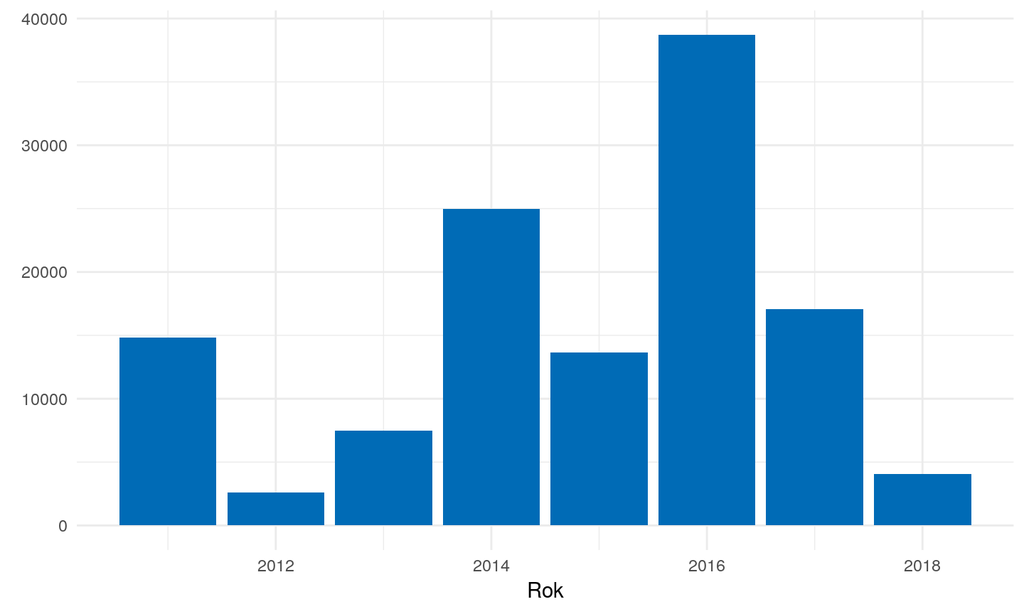

## Realne dane odnośnie turystyki

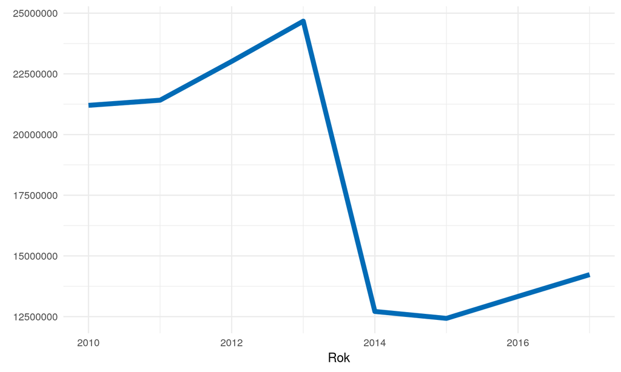

## Realna migracja na Ukrainie - wnioski

Na danych wziętych z Banku Światowego ewidentnie widać pokłosie EURO 2012, bo zainteresowanie Ukrainą zdecydowanie rosło, aż do momentu wkroczenia wojsk rosyjskich na jej teren. Od tego czasu ilość turystów utrzymuje się na prawie dwukrotnie niższym poziomie niz kilka lat wcześniej. Jednakże wraz z upływającym czasem ludzie ponowonie zaczynają się decydować na wizyty na Ukrainie, ze wzgędu na niewątpliwe walory turystyczne tego kraju.

## Podsumowanie

W świetle zebranego materiału nasuwają się następujące wnioski:

- widoczna jest korelacja pomiędzy stopniem rozwinięcia kraju a ilością ludzi chętnych do osiedlenia się w nim,
- wydarzenia takie jak wojna wzbudzają emocje wszędzie, jednakże jest to krótkotrwałe zjawisko

## Bonus - gdzie warto wyemigrować?

[interactive chart not shown]